# Exercise 5

Gerko Vink

Fundamental Techniques in Data Science with R

We use the following packages in this Practical:

```r
library(dplyr)
library(magrittr)
library(ggplot2)
```

In this practical you will need to perform regression analysis and create plots with ggplot2. I give you some examples and ask from you to apply the techniques I demonstrate. For some exercises I give you the solution (e.g. the resulting graph) and the interpretation. The exercise is then to provide to me the code that generates the solution and give me the interpretation for the exercises where this is omitted.

Feel free to ask me, if you have questions.

All the best,

Gerko

# Models and output

1. **Fit the following linear models on the anscombe data:**
- `y1` predicted by `x1` - stored in object `fit1`
- `y2` predicted by `x2` - stored in object `fit2`
- `y3` predicted by `x3` - stored in object `fit3`
- `y4` predicted by `x4` - stored in object `fit4`

I give you the code for first regression model. You need to fit the other three models yourself.

```r
fit1 <- anscombe %$%
  lm(y1 ~ x1)
```

2. **`Display a data frame with the coefficients of the 4 fitted objects from Exercise 1**

Use the following code to markup your output into a nice format

```r
output <- data.frame(fit1 = coef(fit1),
                     fit2 = coef(fit2),
                     fit3 = coef(fit3),
                     fit4 = coef(fit4))
row.names(output) <- names(coef(fit1))
```

3. **Inspect the estimates for the four models in the `output` object. What do you conclude?**

# Plotting the relation

4. **Plot the pair `(x1, y1)` such that `y1` is on the Y-axis and make the color of the points blue** This is quite simple to do with `ggplot2`

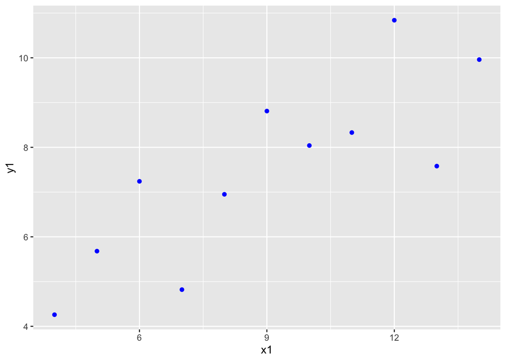

```r
anscombe %>%
  ggplot(aes(x = x1, y = y1)) +
  geom_point(color = "blue")
```

In the above code we put the aesthetics `aes(x = x1, y = y1)` in the `ggplot()` function. This way, the aesthetics hold for the whole graph (i.e. all `geoms` we specify), unless otherwise specified. Alternatively, we could specify aesthetics for individual `geom`’s, such as in

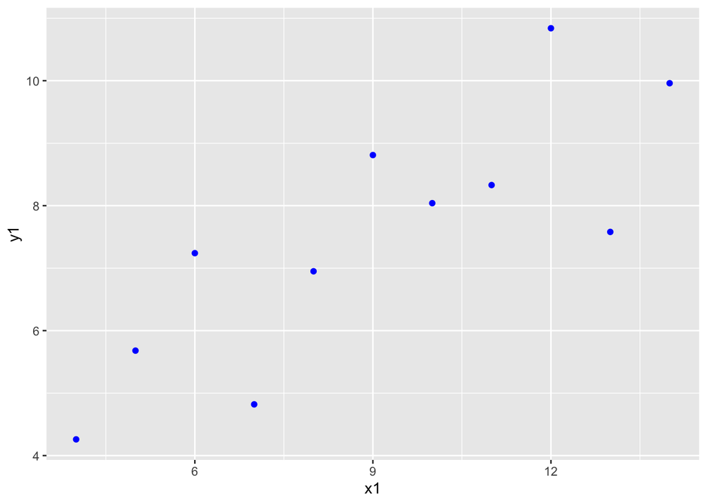

```r
anscombe %>%
  ggplot() +
  geom_point(aes(x = x1, y = y1), color = "blue")
```

We can also override the `aes(x = x1, y = y1)` specified in `ggplot()` by specifying a different `aes(x = x2, y = y2)` under `geom_point()`.

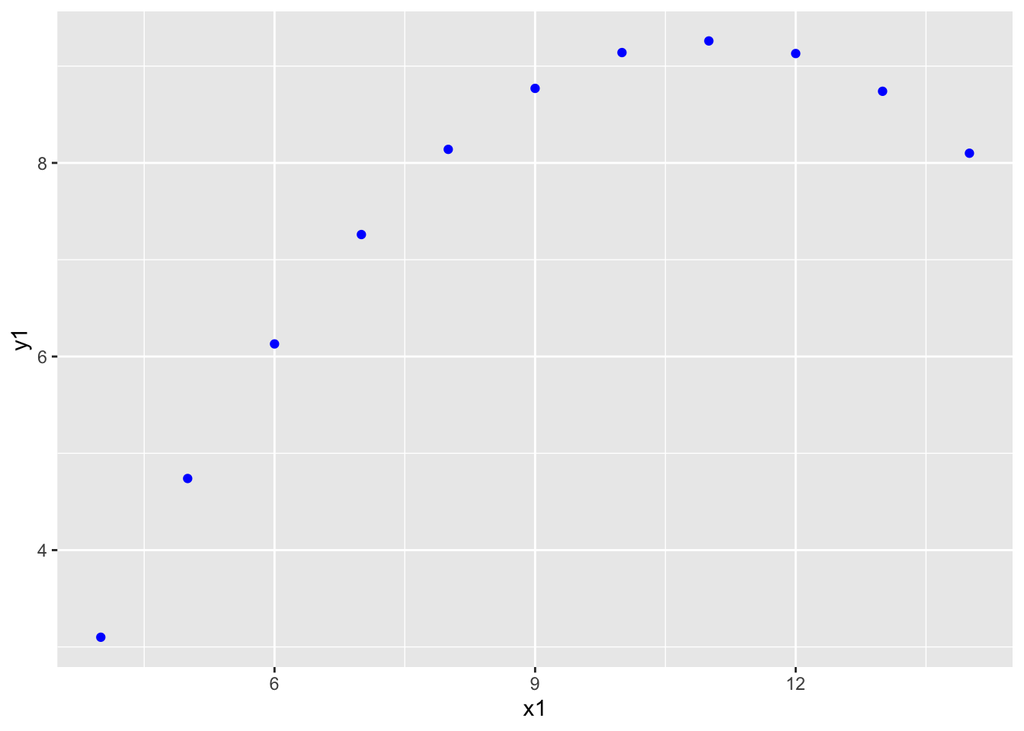

```r
anscombe %>%
  ggplot(aes(x = x1, y = y1)) +
  geom_point(aes(x = x2, y = y2), color = "blue")
```

5. **Plot the four pairs of variables from Exercise 1 in a single plotting window. Make the points in the plots `blue`, `gray`, `orange` and `purple`, respectively.**

In other words, create the following plot:

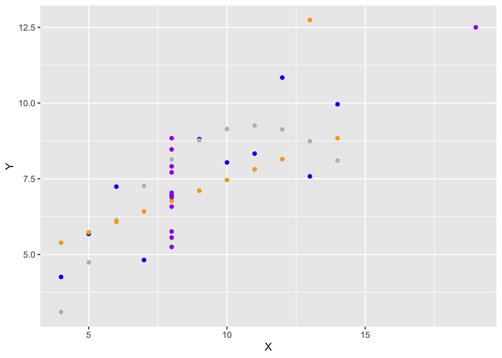

6. **Add a regression line to the plot for only the pairs `(y3, x3)` and `(y4, x4)` where the line inherits the colour from the respective points.** Hint: use `geom_smooth()`.

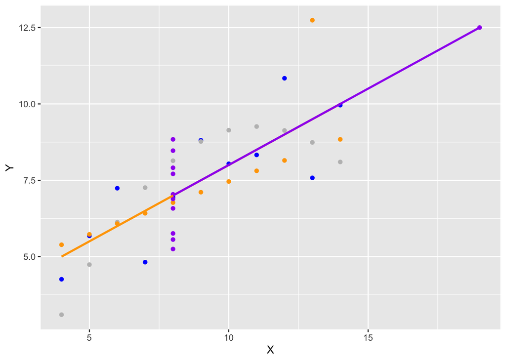

7. **Now add a loess line to the plot from `Exercise 5` for *all pairs but* `(y4, x4)` where the line inherits the colour from the respective points.**

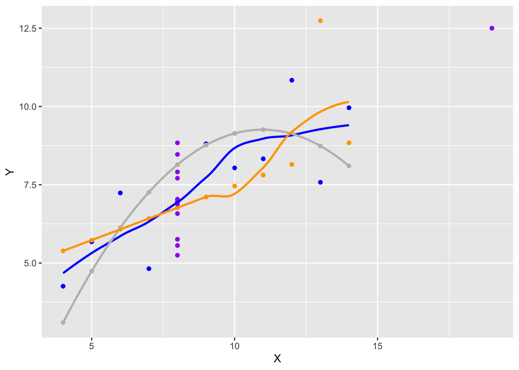

End of practical.